# Advanced Tree Models – Random Forests

In this lab, we will cover some state-of-the-art techniques in the framework of tree models. We use the same datasets as in previous lab, Boston Housing data and Credit Scoring data.

```r
# load Boston data
library(MASS)
data(Boston)
index <- sample(nrow(Boston),nrow(Boston)*0.9)
boston.train <- Boston[index,]
boston.test <- Boston[-index,]

# load credit card data
credit.data <- read.csv("data/credit_default.csv", header=T)
# convert categorical variables
credit.data$SEX<- as.factor(credit.data$SEX)
credit.data$EDUCATION<- as.factor(credit.data$EDUCATION)
credit.data$MARRIAGE<- as.factor(credit.data$MARRIAGE)
# random splitting
index <- sample(nrow(credit.data),nrow(credit.data)*0.9)
credit_train = credit.data[index,]
credit_test = credit.data[-index,]
```

# 1 Random Forests

Random forest is an extension of Bagging, but it makes significant improvement in terms of prediction. The idea of random forests is to randomly select $m$ out of $p$ predictors as candidate variables for each split in each tree. Commonly, $m=\sqrt{p}$. The reason of doing this is that it can *decorrelates* the trees such that it reduces variance when we aggregate the trees. You may refer [Wikipedia](https://en.wikipedia.org/wiki/Random_forest) and the [tutorial](https://www.stat.berkeley.edu/~breiman/RandomForests/cc_home.htm) on the author’s website.

## 1.1 Random Forest for Regression

We start with Boston Housing data.

```r
library(randomForest)
boston.rf<- randomForest(medv~., data = boston.train, importance=TRUE)
boston.rf
```

```
##
## Call:
##  randomForest(formula = medv ~ ., data = boston.train, importance = TRUE)
##                Type of random forest: regression
##                      Number of trees: 500
## No. of variables tried at each split: 4
##
##           Mean of squared residuals: 10.66208
##                     % Var explained: 86.88
```

```r
costMatrix <- matrix(c(0,10,1,0), nrow=2)
mod_rf <- randomForest(medv~., data=boston.train,
                       importance=TRUE, ntree=500,
                       parms = list(loss=costMatrix))
```

By default, $m=p/3$ for regression tree, and $m=\sqrt{p}$ for classification problem. You can change it by specifying `mtry=`. You can also specify number of trees by `ntree=`. The default is 500. The argument `importance=TRUE` allows us to see the variable imporatance.

```r
boston.rf$importance
```

```
##            %IncMSE IncNodePurity
## crim    10.6796170     2472.1065
## zn       0.8643399      292.6399
## indus    7.0087621     2014.5969
## chas     0.5384729      203.7907
## nox      9.2716409     2230.2070
## rm      32.1544621    10449.6398
## age      5.0150906     1139.9247
## dis      7.6198815     2293.0365
## rad      2.0093556      370.3408
## tax      3.8640220     1070.3197
## ptratio  6.8253966     2239.8904
## black    1.4780172      702.7881
## lstat   59.9179831    10715.2766
```

```r
mod_rf$importance
```

```
##            %IncMSE IncNodePurity
## crim     9.7572062     2356.7010
## zn       0.7664377      270.5876
## indus    6.5115157     2016.9029
## chas     0.7849941      262.3364
## nox      9.2022046     2208.2787
## rm      32.3857296    10379.6437
## age      3.9065301      983.0135
## dis      7.2171375     2432.8694
## rad      1.5336546      345.8325
## tax      4.9562588     1316.2532
## ptratio  6.8778011     2366.0923
## black    1.3807004      700.1850
## lstat   61.8102175    10639.6214
```

The MSR is MSE of *out-of-bag* prediction (recall the OOB in bagging). The fitted randomForest actually saves all OOB errors for each `ntree` value from 1 to 500. We can make a plot to see how the OOB error changes with different `ntree`.

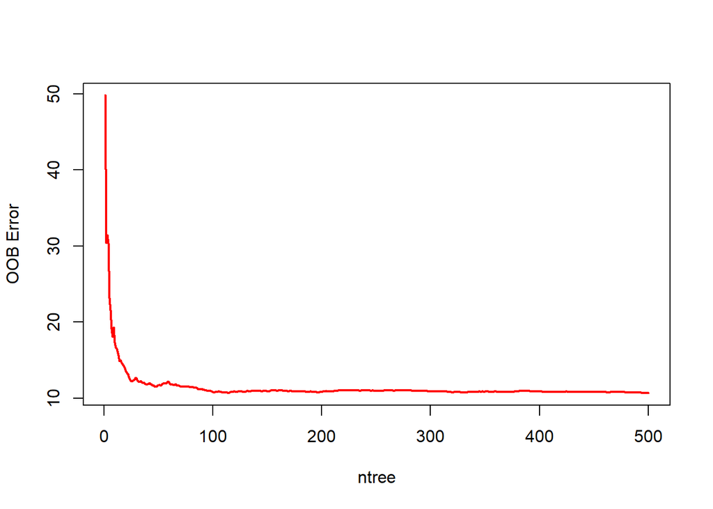

```r
plot(boston.rf$mse, type='l', col=2, lwd=2, xlab = "ntree", ylab = "OOB Error")
```

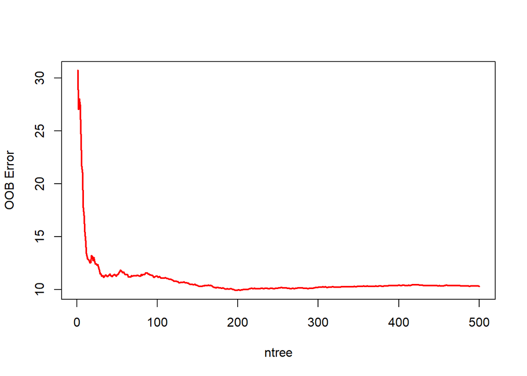

```r
plot(mod_rf$mse, type='l', col=2, lwd=2, xlab = "ntree", ylab = "OOB Error")
```

Prediction on the testing sample.

```r
boston.rf.pred<- predict(boston.rf, boston.test)
mean((boston.test$medv-boston.rf.pred)^2)
```

```
## [1] 9.447316
```

As we mentioned before, the number of candidate predictors in each split is $m\approx \sqrt{p}=\sqrt{13}\approx 4$. We can also specify $m$ with argument `mtry`. Now let’s see how the OOB error and testing error changes with `mtry`.

```r
oob.err<- rep(0, 13)
test.err<- rep(0, 13)
for(i in 1:13){
  fit<- randomForest(medv~., data = boston.train, mtry=i)
  oob.err[i]<- fit$mse[500]
  test.err[i]<- mean((boston.test$medv-predict(fit, boston.test))^2)
  cat(i, " ")
}
```

```
## 1  2  3  4  5  6  7  8  9  10  11  12  13
```

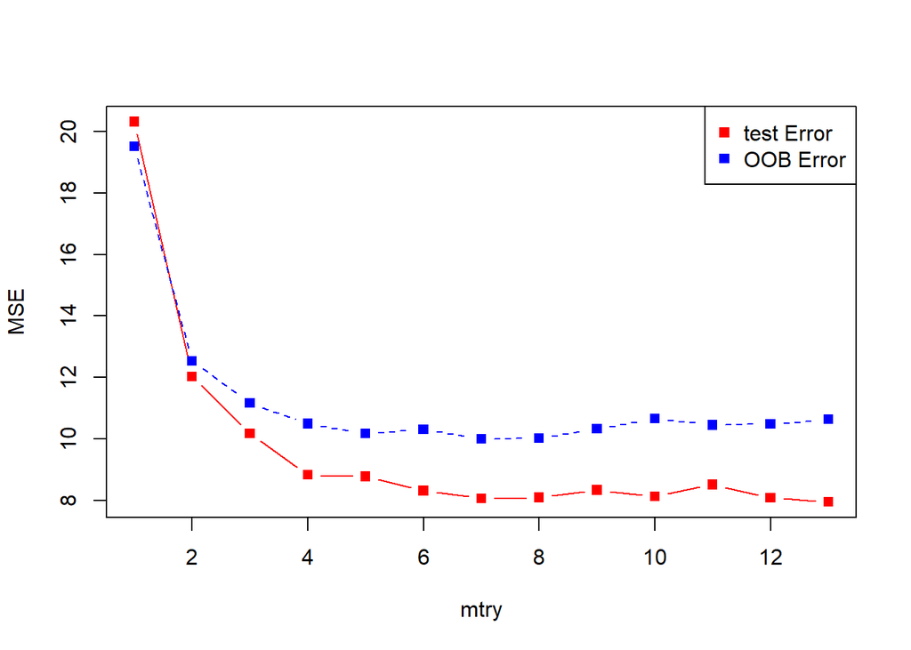

```r
matplot(cbind(test.err, oob.err), pch=15, col = c("red", "blue"), type = "b", ylab = "MSE", xlab = "mtry")
legend("topright", legend = c("test Error", "OOB Error"), pch = 15, col = c("red", "blue"))
```

> Exercise:

> Create a plot displaying the test error across `ntree=`1, …, 500, and `mtry=` 1, …, 13. (You can draw 13 lines in different color representing each $m$).

## 1.2 Random Forest for Classification

```r
credit_rf <- randomForest(as.factor(default.payment.next.month)~.,
                          data = credit_train)
credit_rf
```

```
##
## Call:
##  randomForest(formula = as.factor(default.payment.next.month) ~      ., data = credit_train)
##                Type of random forest: classification
##                      Number of trees: 500
## No. of variables tried at each split: 4
##
##         OOB estimate of  error rate: 18.32%
## Confusion matrix:
##      0   1 class.error
## 0 7946 479   0.0568546
## 1 1500 875   0.6315789
```

```r
costMatrix <- matrix(c(0,100,1,0), nrow=2)
credit_asy_rf <- randomForest(as.factor(default.payment.next.month)~.,
                              data=credit_train,
                              importance=TRUE, ntree=500,
                              parms = list(loss=costMatrix))
credit_asy_rf
```

```
##
## Call:
##  randomForest(formula = as.factor(default.payment.next.month) ~      ., data = credit_train, importance = TRUE, ntree = 500, parms = list(loss = costMatrix))
##                Type of random forest: classification
##                      Number of trees: 500
## No. of variables tried at each split: 4
##
##         OOB estimate of  error rate: 18.1%
## Confusion matrix:
##      0   1 class.error
## 0 7947 478  0.05673591
## 1 1477 898  0.62189474
```

We can again easily plot the error rate vs. ntree. However, as far as I know, `randomForest` does not support asymmetric loss either. So it always uses the overall misclassification rate as the error.

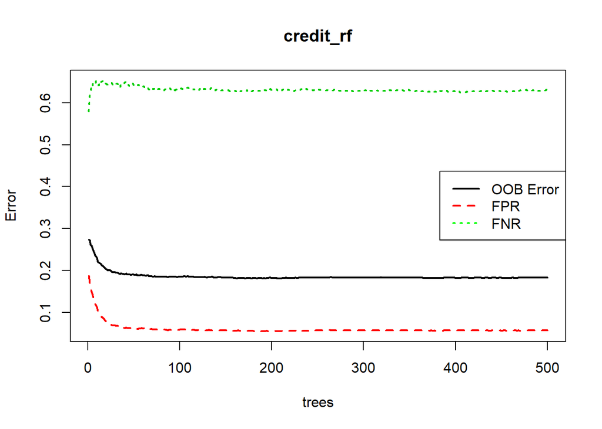

```r
plot(credit_rf, lwd=rep(2, 3))
legend("right", legend = c("OOB Error", "FPR", "FNR"), lwd=rep(2, 3), lty = c(1,2,3), col = c("black", "red", "green"))
```

As we can see, the FNR is very high, just as the confusion matrix.

```r
credit_rf_pred <- predict(credit_rf, type = "prob")[,2]
costfunc = function(obs, pred_p){
    weight1 = 5   # define the weight for "true=1 but pred=0" (FN)
    weight0 = 1    # define the weight for "true=0 but pred=1" (FP)
    pcut <- weight0/(weight0+weight1) # use the weights to decide pcut
    c1 = (obs==1)&(pred_p<pcut)    # count for "true=1 but pred=0"   (FN)
    c0 = (obs==0)&(pred_p>=pcut)   # count for "true=0 but pred=1"   (FP)
    cost = mean(weight1*c1 + weight0*c0)  # misclassification with weight
    return(cost) # you have to return to a value when you write R functions
}
```

ROC curve and AUC can be obtained based on the probability prediction.

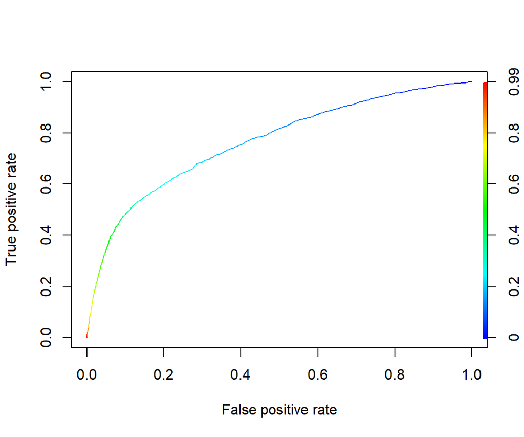

```r
library(ROCR)
pred <- prediction(credit_rf_pred, credit_train$default.payment.next.month)
perf <- performance(pred, "tpr", "fpr")
plot(perf, colorize=TRUE)
```

```r
#Get the AUC
unlist(slot(performance(pred, "auc"), "y.values"))
```

```
## [1] 0.764616
```

Create the confusion matrix based on the optimal cutoff probability from asymmetric cost (pcut=1/6).

```r
## out-of-sample
pcut <- 1/6
credit_rf_pred.test <- predict(credit_rf, newdata=credit_test, type = "prob")[,2]
credit_rf_class_test <- (credit_rf_pred.test>pcut)*1
table(credit_test$default.payment.next.month, credit_rf_class_test, dnn = c("True", "Pred"))
```

```
##     Pred
## True   0   1
##    0 573 370
##    1  68 189
```